# Benchmarking in an ’Omics scanning context

## Background: Performance Metrics and the Confusion Matrix

There are many metrics that are typically reported when evaluating the performance of machine learning based AMP prediction methods (see for example Xu et al (Xu et al. 2021) ). At their core, all of these metrics are based on the four quantities that make up the “confusion matrix,” and which represent modes of successful classification (TN, TP) and modes of failure (FP, FN):

[output not shown]

Where the abbreviations are as follows:

- TP: True Positives
- TN: True Negatives
- FP: False Positives
- FN: False Negatives

When reporting performance of a new predictor, or performing a methods review it is common to report some or all of these measures. In such cases a single value per metric per predictor is typically reported, however, it is important to recognise that for a given predictor the values of the confusion matrix and associated performance metrics will depend on two additional key factors;

1. The classification threshold,

[figure not shown]

   . Usually the probability calculated by the model that a sequence is an AMP
2. The balance of the test dataset,

[figure not shown]

   . This is the proportion of true AMP sequences in the data.

There is a strong convention (adhered to in almost all papers) that these two values should be set as (

[figure not shown]

) when calculating the single valued metrics mentioned above. Another class of metrics measures the area under a curve, generated by varying the value of

[figure not shown]

from 0 through to 1. While these metrics (AUPRC, AUROC) do not explicitly choose

[figure not shown]

they still attempt to reduce performance of the predictor to a single value across the range of

[figure not shown]

, placing equal emphasis on all parts of this range.

In this section we show that these conventions on benchmarking are a poor fit for ’omics scanning applications, where two key considations come into play:

1. The value of

[figure not shown]

   is typically very small (ie AMPs are a minority class, typically on the order of 1% of sequences in the input).
2. Obtaining a high value for precision

[figure not shown]

   is important, and in order to achieve this it is often necessary to work in a regime where

[figure not shown]

   is much higher than 0.5

## Relationship between Precision-Recall curves and

[figure not shown]

[figure not shown]

.

To understand this interaction between alpha and the choice of probability threshold, p we explore the consequences of changes to alpha on the confusion matrix and associated metrics. For simplicity this analysis uses prediction outputs from ampir, however the same principles will apply to other predictors.

First consider how the confusion matrix scales with alpha. This can be calculated by recognising that both TP and FN are actually AMPs and therefore scale with alpha, whereas TN and FP are actually non-AMP and will therefore scale with (1-alpha).

TP = TP * alpha TN = TN * (1-alpha) FP = FP * (1-alpha) FN = FN * alpha

The reference proteomes for the organisms *Homo sapiens* (human), proteome ID: up000005640, and *Arabidopsis thaliana* (mouse-ear cress), proteome ID: up000006548, were downloaded from UniProt proteomes (accessed 23 Jan 2021). *H. sapiens* contained 20,379 reviewed proteins and 55,398 unreviewed proteins. *A. thaliana* contained 15,956 reviewed and 23,390 unreviewed proteins.

```r
human_proteome <- read_tsv("data/proteomes/uniprot-proteome UP000005640.tab") %>% mutate(Label = case_when(str_detect(`Keyword ID`, "KW-0929") ~ "Pos", TRUE ~ "Neg"))
cress_proteome <- read_tsv("data/proteomes/uniprot-proteome UP000006548.tab") %>% mutate(Label = case_when(str_detect(`Keyword ID`, "KW-0929") ~ "Pos", TRUE ~ "Neg"))

reference_proteomes <- rbind(human_proteome, cress_proteome)
```

## ampir

```r
cress_pred_ampir_prec <- cress_proteome %>% select(`Entry name`, Sequence) %>% as.data.frame() %>% predict_amps(n_cores = 3) %>% add_column(Model = "ampir_precursor")

cress_pred_ampir_mat <- cress_proteome %>% select(`Entry name`, Sequence) %>% as.data.frame() %>% predict_amps(n_cores = 3, model = "mature")%>% add_column(Model = "ampir_mature")

human_pred_ampir_prec <- human_proteome %>% select(`Entry name`, Sequence) %>% as.data.frame() %>% predict_amps(n_cores = 3) %>% add_column(Model = "ampir_precursor")

human_pred_ampir_mat <- human_proteome %>% select(`Entry name`, Sequence) %>% as.data.frame() %>% predict_amps(n_cores = 3, model = "mature")  %>% add_column(Model = "ampir_mature")
```

In addition to ampir’s standard models (`ampir_precursor` and `ampir_mature`), a special model was trained with sequences present in the `ampir_precursor` model, **minus** any *H. sapiens* or *A. thaliana* proteins (see ampir’s analysis repository, AMP_pub, workflow 02_build_training_data for details). This was done to remove any potential biases when testing the trained models on the *H. sapiens* and *A. thaliana* proteomes.

```r
ampir_prec_model_nobench <- readRDS("data/ampir_v1/tuned_precursor_imbal_nobench.rds")

cress_pred_ampir_nobench <- cress_proteome %>% select(`Entry name`, Sequence) %>% as.data.frame() %>% predict_amps( n_cores=1, model = ampir_prec_model_nobench) %>% add_column(Model = "ampir_precursor_nobench")

human_pred_ampir_nobench <- human_proteome %>% select(`Entry name`, Sequence) %>% as.data.frame() %>% predict_amps( n_cores=1, model = ampir_prec_model_nobench) %>% add_column(Model = "ampir_precursor_nobench")
```

```r
ampir_proteome_predictions <- rbind(cress_pred_ampir_prec, cress_pred_ampir_mat, cress_pred_ampir_nobench, human_pred_ampir_prec, human_pred_ampir_mat, human_pred_ampir_nobench) %>% left_join(reference_proteomes, by = "Entry name") %>% select(ID = `Entry name`, prob_AMP, Organism, Label, Model)
```

Use ampir v1.1.0 models (updated with additional AMPs) as well as a balanced model

```r
ampirv1.1_precursor_imbal <- readRDS("data/ampir_v1.1.0_data/tuned_precursor_imbal_full.rds")

ampirv1.1_mature <- readRDS("data/ampir_v1.1.0_data/tuned_mature_full.rds")

ampirv1.1_precursor_bal <- readRDS("data/ampir_v1.1.0_data/tuned_precursor_bal_full.rds")

cress_pred_ampirv1.1_prec_imbal <- cress_proteome %>% select(`Entry name`, Sequence) %>% as.data.frame() %>% predict_amps(n_cores = 3, model = ampirv1.1_precursor_imbal) %>% add_column(Model = "ampir_v1.1_precursor_imbal")

cress_pred_ampirv1.1_prec_bal <- cress_proteome %>% select(`Entry name`, Sequence) %>% as.data.frame() %>% predict_amps(n_cores = 3, model = ampirv1.1_precursor_imbal) %>% add_column(Model = "ampir_v1.1_precursor_bal")

cress_pred_ampirv1.1_mat <- cress_proteome %>% select(`Entry name`, Sequence) %>% as.data.frame() %>% predict_amps(n_cores = 3, model = ampirv1.1_mature )%>% add_column(Model = "ampir_v1.1_mature")

human_pred_ampirv1.1_prec_imbal <- human_proteome %>% select(`Entry name`, Sequence) %>% as.data.frame() %>% predict_amps(n_cores = 3, model = ampirv1.1_precursor_imbal) %>% add_column(Model = "ampir_v1.1_precursor_imbal")

human_pred_ampirv1.1_prec_bal <- human_proteome %>% select(`Entry name`, Sequence) %>% as.data.frame() %>% predict_amps(n_cores = 3, model = ampirv1.1_precursor_imbal) %>% add_column(Model = "ampir_v1.1_precursor_bal")

human_pred_ampirv1.1_mat <- human_proteome %>% select(`Entry name`, Sequence) %>% as.data.frame() %>% predict_amps(n_cores = 3, model = ampirv1.1_mature) %>% add_column(Model = "ampir_v1.1_mature")

ampir_v1.1prec_model_nobench <- readRDS("data/ampir_v1.1.0_data/tuned_precursor_imbal_nobench.rds")

cress_pred_ampirv1.1_nobench <- cress_proteome %>% select(`Entry name`, Sequence) %>% as.data.frame() %>% predict_amps( n_cores=1, model = ampir_v1.1prec_model_nobench) %>% add_column(Model = "ampir_v1.1_precursor_imbal_nobench")

human_pred_ampirv1.1_nobench <- human_proteome %>% select(`Entry name`, Sequence) %>% as.data.frame() %>% predict_amps( n_cores=1, model = ampir_v1.1prec_model_nobench) %>% add_column(Model = "ampir_v1.1_precursor_imbal_nobench")

ampir_v1.1_proteome_predictions <- rbind(cress_pred_ampirv1.1_prec_imbal, cress_pred_ampirv1.1_prec_bal, cress_pred_ampirv1.1_mat, cress_pred_ampirv1.1_nobench, human_pred_ampirv1.1_prec_imbal, human_pred_ampirv1.1_prec_bal, human_pred_ampirv1.1_mat,human_pred_ampirv1.1_nobench) %>% left_join(reference_proteomes, by = "Entry name") %>% select(ID = `Entry name`, prob_AMP, Organism, Label, Model)
```

To use the human and *Arabidopsis* proteomes in other predictors, first the non-standard amino acids are removed. This is because the majority of AMP predictors only accept sequences that contain standard amino acids. ampir contains a function that removes everything which is not a standard amino acid, but other predictors, such as AMP scanner, require sequences to be preprocessed to have these sequences removed prior to analysing the sequences. Therefore, the `remove_nonstandard_aa.R` function from ampir is used to remove sequences that contain nonstandard amino acids, and ampir’s `df_to_faa.R` function is used to write the files as FASTA files as input to other predictors. In addition, due to sequence amount restrictions using predictor web interfaces, the *Arabidopsis* proteome is split in half and the human proteome is split threefold.

```r
arab_prot_clean <- read_faa("data/proteomes/arabidopsis-proteomeUP000006548.fasta") %>% remove_nonstandard_aa()
df_to_faa(arab_prot_clean, "cache/arab_proteome_standardaa.fasta")

arab_prot_clean %>% slice((1:19669)) %>% df_to_faa("cache/arab_prot_clean1.fasta")
arab_prot_clean %>% slice((19670:n())) %>% df_to_faa("cache/arab_prot_clean2.fasta")

homo_prot_clean <- read_faa("data/proteomes/human-proteomeUP000005640.fasta") %>% remove_nonstandard_aa()
df_to_faa(homo_prot_clean, "cache/homo_proteome_standardaa.fasta")

homo_prot_clean %>% slice((1:22494)) %>% df_to_faa("cache/homo_prot_clean1.fasta")
homo_prot_clean %>% slice((22495:44988)) %>% df_to_faa("cache/homo_prot_clean2.fasta")
homo_prot_clean %>% slice((44989:n())) %>% df_to_faa("cache/homo_prot_clean3.fasta")
```

## Antimicrobial Peptide Scanner vr. 2

AMP scanner vr. 2 (model Feb 2020)

```r
ampscanner_file_paths <- c(list.files("data/prediction_results/ampscanner_v2", pattern="*.csv",full.names = T))

ampscan_genome_bench <- do.call(rbind,lapply(ampscanner_file_paths,read_csv)) %>%
  separate(SeqID,into = c("database","Entry","Entry name"),sep = "\\|") %>%
  left_join(reference_proteomes,by="Entry name") %>%
  select(ID = `Entry name`, prob_AMP = Prediction_Probability, Organism, Label) %>%
  add_column(Model = "AMPscanner_v2")
```

## amPEP

```r
ampep_file_paths <- c("data/prediction_results/ampep/arab_proteome_standardaa_ampep.txt","data/prediction_results/ampep/homo_proteome_standardaa_ampep.txt")

ampep_genome_bench <- do.call(rbind,lapply(ampep_file_paths,read_csv)) %>%
  separate(Row, into = c("database","Entry","Entry name"),sep = "\\|") %>%
  left_join(reference_proteomes, by = "Entry name") %>%
  select(ID = `Entry name`, prob_AMP = score, Organism, Label) %>%
  add_column(Model = "amPEP")
```

## amPEPpy

```bash
ampep predict -m pretrained_models/amPEP.model -i ../cache/arab_proteome_standardaa.fasta -o arab_results.tsv --seed 2012
ampep predict -m pretrained_models/amPEP.model -i ../cache/homo_proteome_standardaa.fasta -o homo_results.tsv --seed 2012
```

```r
ampeppy_file_paths <- list.files("data/prediction_results/amPEPpy", pattern="*.tsv",full.names = T)

ampeppy_genome_bench <- do.call(rbind,lapply(ampeppy_file_paths,read_tsv)) %>%
  separate(seq_id, into = c(NA, NA,"Entry name"),sep = "\\|") %>%
  left_join(reference_proteomes, by = "Entry name") %>%
  select(ID = `Entry name`, prob_AMP = probability_AMP, Organism, Label) %>%
  add_column(Model = "amPEPpy")
```

## AMPlify

AMPlify v1.0.0 was installed as the latest release from [AMPlify’s repository](https://github.com/bcgsc/AMPlify). However, when using AMPlify to predict proteins an error arose, related to the software itself, and therefore unfortunately could not be included in the benchmark. An issue was raised with details about this error on the [AMPlify’s issue page](https://github.com/bcgsc/AMPlify/issues/1) on 10/02/2021.

Update: when looking at the commit history, a [commit](https://github.com/bcgsc/AMPlify/commit/2c44491b7a8f4815b154307f5b250f991942935a) was found which looked like it would fix the issue. After installing the released version, I changed the source code for the software according to the previously mentioned commit, and the software worked after that.

AMPlify is optimised for protein sequences that are 200 AA or less and do not allow input data to contain sequences larger than 200 amino acids. Therefore, only proteins that were =< 200 AA were kept in the proteomes (9,027 for *A. thaliana* from 39,340 standard AA sequences and 33,584 for *H. sapiens* from 67,484 standard AA sequences)

```bash
cat data/prediction_results/AMPlify1.0.0/AMPlify_results_20210405153447_Athaliana.txt | sed 's/\r//' | awk '$0~/^Sequence ID:/{spid=$3};$0~/^Score:/{printf("%s\t%s\n",spid,$2)}' > data/prediction_results/AMPlify1.0.0/AMPlify_Athaliana.txt

cat data/prediction_results/AMPlify1.0.0/AMPlify_results_20210405182202_Hsapiens.txt | sed 's/\r//' | awk '$0~/^Sequence ID:/{spid=$3};$0~/^Score:/{printf("%s\t%s\n",spid,$2)}' > data/prediction_results/AMPlify1.0.0/AMPlify_Hsapiens.txt
```

```r
amplify_file_paths <- c("data/prediction_results/AMPlify1.0.0/AMPlify_Athaliana.txt","data/prediction_results/AMPlify1.0.0/AMPlify_Hsapiens.txt")

amplify_genome_bench <- do.call(rbind,lapply(amplify_file_paths,read_delim, delim = "\t", col_names = c("Entry name", "prob_AMP"))) %>%
  separate(`Entry name`, into = c(NA, NA,"Entry name"),sep = "\\|") %>%
  left_join(reference_proteomes, by = "Entry name") %>%
  select(ID = `Entry name`, prob_AMP, Organism, Label) %>%
  add_column(Model = "AMPlify")
```

## AMPgram

In order to significantly speed up the progress of using AmpGram on the *A. thaliana* and *H. sapiens* proteomes, high performance computing (HPC) scheduler (PBS) with job arrays submissions were used. To accomplish this, first, both proteomes were split into FASTA files containing 100 protein sequences (394 FASTA files for *A. thaliana* and 675 for *H. sapiens*) using the scripts `scripts/subset_arab_file.zsh` and `subset_homo_proteome.zsh`. Per job, approximately 100 subjobs which referenced to 100 FASTA files were used. See `scripts/runampgram_h1.sh` and `scripts/runampgram_h1.R` as example scripts used for the first 100 subjobs/FASTA files from the *H. sapiens* proteome.

Initially when the jobs were submitted, various subjobs failed (three for *A. thaliana* and 62 for *H. sapiens*). After examining the [source code for AmpGram](https://github.com/michbur/AmpGram/blob/master/R/utils.R), it appears that AmpGram does not support sequences less than 10 amino acids long. In the *A. thaliana* proteome (with non standard amino acids removed) there were three proteins less than 10 amino acids long and in *H. sapiens* there were 268. Therefore these sequences were not included in the prediction analysis from AmpGram.

*AmpGram’s prediction results is a list for each protein prediction that is subdivided into three sublists. For this benchmark analysis, only the third sublist is relevant as this contains the probability score for that protein. A function was written to easily extract this probability score and associated protein name from each output file.

```r
gimme_ampgram_predictions <- function(filepath) {

  ampgram_list <- readRDS(filepath)

  amgram_probandnamelist <- lapply(ampgram_list, '[[', 3)

  bind_rows(amgram_probandnamelist, .id = "ID")
}
```

```r
if (file.exists("cache/ampgram_genome_bench.rds")) {
  ampgram_genome_bench <- readRDS("cache/ampgram_genome_bench.rds")
} else {

ampgram_filepaths <- list.files(c("data/prediction_results/ampgram/homo", "data/prediction_results/ampgram/homo/leftovers", "data/prediction_results/ampgram/arab"), pattern="*.rds",full.names = T)

ampgram_predictions <- map_df(ampgram_filepaths, gimme_ampgram_predictions)

ampgram_genome_bench <- ampgram_predictions %>%
  separate(ID, into = c(NA, NA,"Entrynamewdescr"),sep = "\\|") %>%
  separate(Entrynamewdescr, into = c("Entry name", NA), sep = "\t", fill = "left") %>%
  left_join(reference_proteomes, by = "Entry name") %>%
  select(ID = `Entry name`, prob_AMP = "TRUE", Organism, Label) %>%
  add_column(Model = "AmpGram")
}
```

### Calculating performance metrics - ROC curves

A function, `get_genome_roc.R` was written to use `calc_cm_metrics.R` to calculate performance metrics over a range of predicted probability (0 - 0.99) values, which include metrics necessary to construct ROC curves (false positive rate and true positive rate)

```r
source("scripts/calc_cm_metrics.R")

organisms = c("Homo sapiens (Human)","Arabidopsis thaliana (Mouse-ear cress)")

get_genome_roc <- function(data, model_name){
  do.call(rbind,lapply(organisms,function(org){
    map_df(c(seq(0.01, 0.99, 0.01),seq(0.99, 0.990, 0.001)), calc_cm_metrics, data %>% filter(Organism==org)) %>%
    add_column(Organism = org)
  })) %>%
  add_column(Model = model_name)
}
```

To use `get_genome_roc.R` on ampir data, an additional loop had to be implemented as in this case, ampir is subdivided into three different models and therefore metric calculations needed to be done three different times, one for each model.

```r
ampir_genome_roc <- do.call(rbind,lapply(c("ampir_precursor","ampir_mature", "ampir_precursor_nobench"),function(meth){
    get_genome_roc(ampir_proteome_predictions %>% filter(Model==meth),meth)}))
```

```r
ampscanner_roc <- get_genome_roc(ampscan_genome_bench, "AMPscanner_v2")

ampep_roc <- get_genome_roc(ampep_genome_bench, "amPEP")

ampgram_roc <- get_genome_roc(ampgram_genome_bench, "AmpGram")

ampeppy_roc <- get_genome_roc(ampeppy_genome_bench, "amPEPpy")

amplify_roc <- get_genome_roc(amplify_genome_bench, "AMPlify")
```

*combine ROC metric dataframes*

```r
proteome_rocs <- rbind(ampir_genome_roc, ampscanner_roc, ampep_roc, ampgram_roc, ampeppy_roc, amplify_roc)
```

## Plots

ROC curves, based on the false and true positive rates, and subsequent AUROCs are often used to evaluate model performance but these can be misleadingly confident when used on a dataset that is highly imbalanced, i.e. where one class heavily outweighs the other [Davis & Goadrich 2006](https://doi.org/10.1145/1143844.1143874). A more accurate alternative would be to use precision and recall (PR) curves as these focus on the proportion of actual true positives within the positive predictions [Saito & Rehmsmeier 2015](https://dx.doi.org/10.1371%2Fjournal.pone.0118432), rather than including the true negatives, as the false positive rates in the ROC curves do. As the proportion of AMPs in a genome is extremely low, the AMP prediction models would have to perform on a highly imbalanced dataset and therefore the precision recall curves are additionally used in this study. ROC curves are evaluated on their shape, generally curves that arc closer to the top left corner (similar to a capital gamma Γ shape), as well as their AUC values. The AUC values range between 0.0 and 1.0 where 0.0 the model cannot tell the classes apart at all and 1.0 the model is able to distinguish between classes perfectly. Generally, an AUC of 0.5 already indicates that the model struggles to differentiate between classes. On the ROC curve plot, an AUC of 0.5 makes a diagonal line from the bottom left to the top right corner. The perfect PR curve is like a mirror image of the perfect ROC curve; it bends at the top right corner, which refers to the model performing with 100% recall and precision. Therefore, the more the PR curves bend toward the top right corner, the better the model is. When comparing multiple curves on the same plot, the curve that is above another curve, is generally assumed to perform better.

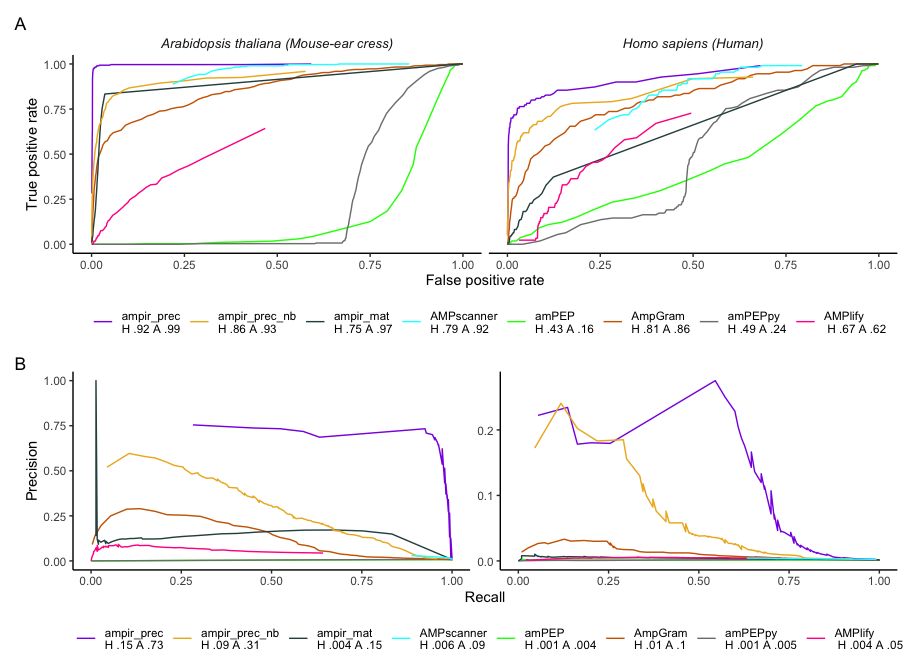

**Figure 3.1:** Performance of various AMP predictors in classifying whole proteome data for *Homo sapiens* and *Arabidopsis thaliana*. Performance is shown as ROC curves (top row) and precision-recall curves (second row). H refers to *Homo sapiens* and A refers to *Arabidopsis thaliana*. The numbers that follow are the respective AUC values for either the ROC or PR curve.

Similar to how the ROC curves were calculated, a function, `get_metrics.R`, was written to calculate performance metrics, which include the area under the curve (AUC) for both the ROC and Precision-recall curves, of the various AMP models tested on the *H. sapiens* and *A. thaliana* proteomes.

```r
source("scripts/calculate_model_metrics.R")

get_metrics <- function(bench_data, model_name) {
  do.call(rbind,lapply(c("Homo sapiens (Human)","Arabidopsis thaliana (Mouse-ear cress)"),function(org){
    calculate_model_metrics(bench_data %>% filter(Organism==org)) %>%
      add_column(Organism = org) %>%
      add_column(Model = model_name)
    }))
}

ampir_metrics <- do.call(rbind, lapply(c("ampir_precursor","ampir_mature", "ampir_precursor_nobench"),function(meth) {
  get_metrics(ampir_proteome_predictions %>% filter(Model==meth), model_name = meth)
}))

ampscan_metrics <- get_metrics(ampscan_genome_bench, "AMPscanner_v2")
ampep_metrics <- get_metrics(ampep_genome_bench, "amPEP")
ampgram_metrics <- get_metrics(ampgram_genome_bench, "AmpGram")
ampeppy_metrics <- get_metrics(ampeppy_genome_bench, "amPEPpy")
amplify_metrics <- get_metrics(amplify_genome_bench, "AMPlify")

proteome_metrics <- rbind(ampir_metrics, ampscan_metrics, ampep_metrics, ampgram_metrics, ampeppy_metrics, amplify_metrics) %>% mutate(Organism = case_when(str_detect(Organism, "Homo") ~ "H. sapiens", TRUE ~ "A. thaliana"))
```

**Table 3.1:** Performance metrics of various predictors on the proteomes of *Homo sapiens* and *Arabidopsis thaliana*

| Specificity | Recall | Precision | F1 | MCC | AUROC | AUPRC | Organism | Model |
| --- | --- | --- | --- | --- | --- | --- | --- | --- |
| 0.971 | 0.755 | 0.041 | 0.078 | 0.172 | 0.918 | 0.150 | H. sapiens | ampir_precursor |
| 0.986 | 0.986 | 0.346 | 0.512 | 0.580 | 0.996 | 0.727 | A. thaliana | ampir_precursor |
| 0.049 | 1.000 | 0.002 | 0.004 | 0.009 | 0.753 | 0.004 | H. sapiens | ampir_mature |
| 0.007 | 1.000 | 0.008 | 0.016 | 0.008 | 0.971 | 0.154 | A. thaliana | ampir_mature |
| 0.970 | 0.573 | 0.030 | 0.057 | 0.127 | 0.860 | 0.090 | H. sapiens | ampir_precursor_nobench |
| 0.988 | 0.554 | 0.258 | 0.352 | 0.371 | 0.927 | 0.312 | A. thaliana | ampir_precursor_nobench |
| 0.499 | 0.918 | 0.003 | 0.006 | 0.034 | 0.787 | 0.006 | H. sapiens | AMPscanner_v2 |
| 0.468 | 0.997 | 0.014 | 0.028 | 0.080 | 0.917 | 0.087 | A. thaliana | AMPscanner_v2 |
| 0.495 | 0.391 | 0.001 | 0.002 | -0.009 | 0.425 | 0.001 | H. sapiens | amPEP |
| 0.484 | 0.024 | 0.000 | 0.000 | -0.085 | 0.158 | 0.004 | A. thaliana | amPEP |
| 0.619 | 0.800 | 0.003 | 0.006 | 0.035 | 0.806 | 0.013 | H. sapiens | AmpGram |
| 0.591 | 0.864 | 0.016 | 0.031 | 0.080 | 0.859 | 0.138 | A. thaliana | AmpGram |
| 0.522 | 0.273 | 0.001 | 0.002 | -0.017 | 0.487 | 0.001 | H. sapiens | amPEPpy |
| 0.316 | 0.031 | 0.000 | 0.000 | -0.121 | 0.240 | 0.005 | A. thaliana | amPEPpy |
| 0.902 | 0.159 | 0.004 | 0.008 | 0.011 | 0.667 | 0.004 | H. sapiens | AMPlify |
| 0.990 | 0.017 | 0.053 | 0.026 | 0.012 | 0.622 | 0.054 | A. thaliana | AMPlify |

```r
#compare ampir v1.0.0 vs ampir v1.1.0

ampir_v1.1_genome_roc <- do.call(rbind,lapply(c("ampir_v1.1_precursor_imbal","ampir_v1.1_precursor_bal","ampir_v1.1_mature","ampir_v1.1_precursor_imbal_nobench"),function(meth){
    get_genome_roc(ampir_v1.1_proteome_predictions %>% filter(Model==meth),meth)}))

ampir_rocs <- rbind(ampir_genome_roc, ampir_v1.1_genome_roc)

ampir_v1.1_metrics <- do.call(rbind, lapply(c("ampir_v1.1_precursor_imbal","ampir_v1.1_precursor_bal","ampir_v1.1_mature","ampir_v1.1_precursor_imbal_nobench"),function(meth) {
  get_metrics(ampir_v1.1_proteome_predictions %>% filter(Model==meth), model_name = meth)
}))

ampir_comparison_metrics <- rbind(ampir_metrics, ampir_v1.1_metrics) %>% mutate(Organism = case_when(str_detect(Organism, "Homo") ~ "H. sapiens", TRUE ~ "A. thaliana"))

ampir_comparison_metrics[,3:11]
```

```
##    Specificity Recall Precision    F1   MCC AUROC AUPRC    Organism
## 1        0.971  0.755     0.041 0.078 0.172 0.918 0.150  H. sapiens
## 2        0.986  0.986     0.346 0.512 0.580 0.996 0.727 A. thaliana
## 3        0.049  1.000     0.002 0.004 0.009 0.753 0.004  H. sapiens
## 4        0.007  1.000     0.008 0.016 0.008 0.971 0.154 A. thaliana
## 5        0.970  0.573     0.030 0.057 0.127 0.860 0.090  H. sapiens
## 6        0.988  0.554     0.258 0.352 0.371 0.927 0.312 A. thaliana
## 7        0.971  0.864     0.047 0.089 0.197 0.932 0.298  H. sapiens
## 8        0.988  0.990     0.375 0.544 0.605 0.998 0.832 A. thaliana
## 9        0.971  0.864     0.047 0.089 0.197 0.932 0.298  H. sapiens
## 10       0.988  0.990     0.375 0.544 0.605 0.998 0.832 A. thaliana
## 11       0.048  1.000     0.002 0.004 0.009 0.755 0.004  H. sapiens
## 12       0.007  1.000     0.008 0.016 0.007 0.971 0.153 A. thaliana
## 13       0.972  0.555     0.032 0.061 0.128 0.848 0.110  H. sapiens
## 14       0.989  0.588     0.280 0.379 0.400 0.946 0.344 A. thaliana
##                                 Model
## 1                     ampir_precursor
## 2                     ampir_precursor
## 3                        ampir_mature
## 4                        ampir_mature
## 5             ampir_precursor_nobench
## 6             ampir_precursor_nobench
## 7          ampir_v1.1_precursor_imbal
## 8          ampir_v1.1_precursor_imbal
## 9            ampir_v1.1_precursor_bal
## 10           ampir_v1.1_precursor_bal
## 11                  ampir_v1.1_mature
## 12                  ampir_v1.1_mature
## 13 ampir_v1.1_precursor_imbal_nobench
## 14 ampir_v1.1_precursor_imbal_nobench
```

```r
write_excel_csv(ampir_comparison_metrics[,3:11], "ampir_comparison.csv")
```

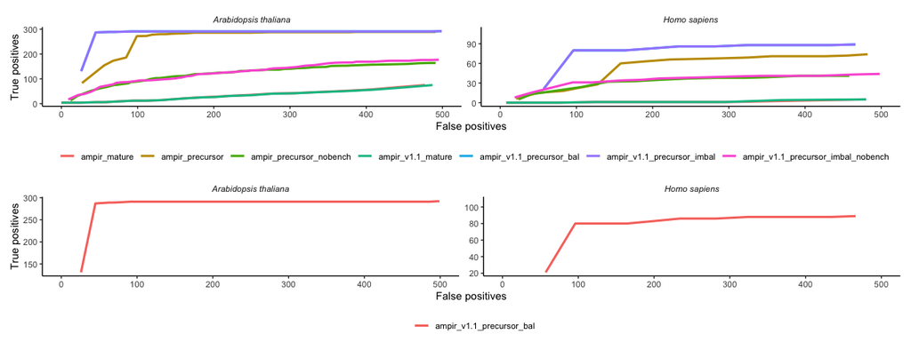

```r
ampir_rocs  <- ampir_rocs  %>% mutate(Organism = case_when(str_detect(Organism, "Homo") ~ "Homo sapiens", TRUE ~ "Arabidopsis thaliana"))

ampir_all <- ggplot(ampir_rocs) +
  geom_line(aes(x = FP, y = TP, colour = Model),size = 1.1) +
  xlim(0,500) +
  facet_wrap(~Organism, scales = "free_y", nrow = 1) +
  labs(x= "False positives", y = "True positives", colour = "") +
  theme_classic() +
  theme(legend.position = "bottom",
        strip.text = element_text(face = "italic"),
        strip.background = element_blank()) +
   guides(colour = guide_legend(nrow = 1))

ampir_bal <- ggplot(filter(ampir_rocs, Model == "ampir_v1.1_precursor_bal")) +
  geom_line(aes(x = FP, y = TP, colour = Model),size = 1.1) +
  xlim(0,500) +
  facet_wrap(~Organism, scales = "free_y", nrow = 1) +
  labs(x= "False positives", y = "True positives", colour = "") +
  theme_classic() +
  theme(legend.position = "bottom",
        strip.text = element_text(face = "italic"),
        strip.background = element_blank()) +
   guides(colour = guide_legend(nrow = 1))

ampir_all / ampir_bal
```

```r
ggsave("ampir_comparison.png", width = 33, height = 18 ,units = "cm" )
```

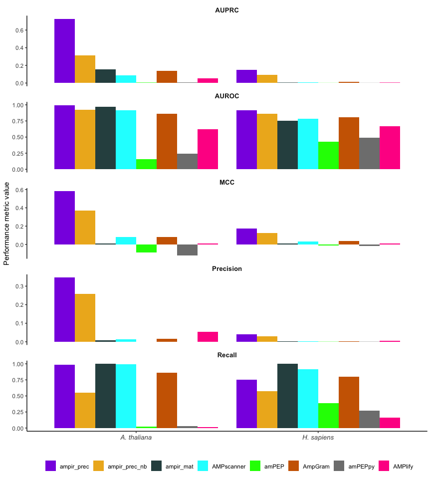

```r
proteome_metrics_long <- proteome_metrics %>%
  select(Recall, Precision, MCC, AUROC, AUPRC, Organism, Model) %>%
  pivot_longer(cols = c(-Organism, -Model)) %>%
  mutate(Model = factor(Model, levels = c("ampir_precursor", "ampir_precursor_nobench", "ampir_mature", "AMPscanner_v2", "amPEP", "AmpGram", "amPEPpy", "AMPlify")))


ggplot(proteome_metrics_long, aes(x = Organism, y = value)) +
  geom_bar(stat = "identity", aes(fill = Model), position = "dodge") +
  facet_wrap(~name, ncol = 1, scales = "free_y") +
  theme_classic() +
  theme(legend.position = "bottom",
        strip.background = element_rect(colour = "white"),
        strip.text = element_text(face = "bold", size = 10),
        axis.text.x = element_text(face = "italic", size = 10)) +
  scale_fill_manual(breaks = c("ampir_precursor", "ampir_precursor_nobench", "ampir_mature",
                               "AMPscanner_v2", "amPEP", "AmpGram", "amPEPpy", "AMPlify"),
                     labels = c("ampir_prec", "ampir_prec_nb", "ampir_mat","AMPscanner", "amPEP", "AmpGram", "amPEPpy", "AMPlify"),
                     values = c("blueviolet", "goldenrod2", "darkslategray", "cyan", "green", "darkorange3", "grey50", "deeppink")) +
  labs(x = "", fill = "", y = "Performance metric value") +
  guides(fill = guide_legend(nrow = 1))
```

```r
ggsave("figures/proteome_metrics_groupedbar.png", width = 21.5, height = 20, units = "cm")
```

The metrics overall are really low for the ability of models to predict AMPs in proteomes. However, these metrics may not be a very informative evaluation.

It is important to remember the real life situation and applications of predictive models. The actual frequency of AMPs (true positives) in a proteome is approximately 1%. This is extremely low. To adequately express the real-world performance of predictors on proteomes, the numbers of true and false positives were used, with a focus on the low false positive regime, as this is what matters most in whole proteome scans (Figure 3.2)

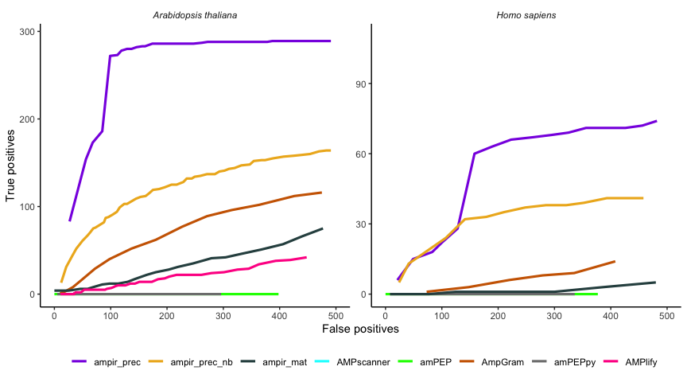

**Figure 3.2:** The ability of various models to predict AMPs in the low false positive regime (<500) in the proteomes of *Arabidopsis thaliana* and *Homo sapiens*. It is scaled so that the limits of the y-axis show the full complement of known AMPs in each genome (294 for *A. thaliana*, 112 for *H. sapiens*), and the limits of the x-axis are restricted to emphasise behaviour in the low false positive (FP) regime (FP < 500).

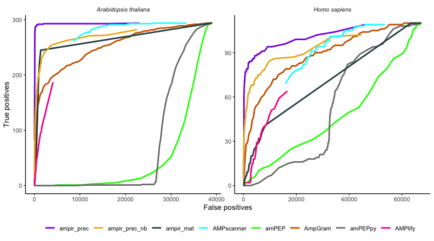

**Figure 3.3:** Same as Figure 3.2 but showing the entire false positive regime

Xu, Jing, Fuyi Li, André Leier, Dongxu Xiang, Hsin-Hui Shen, Tatiana T Marquez Lago, Jian Li, Dong-Jun Yu, and Jiangning Song. 2021. “Comprehensive Assessment of Machine Learning-Based Methods for Predicting Antimicrobial Peptides.” *Brief. Bioinform.*, March.